# 11. Textual Data I

## Processing NLP Pipeline

In this chapter a number of methods are introduced for working with textual data. The idea is that we have a collection of texts and we want to use R to investigate the structure and connections between the various documents. As an example dataset, we will use our standard set of 61 food items. However, instead of the typical metadata, we will use a new dataset consisting of the text from each item’s Wikipedia page. Later chapters will show how to construct this dataset within R; for now we will work with it as-is.

```r
page_text
```

```
## # A tibble: 61 x 2
##    item        page_text
##    <chr>       <chr>
##  1 Apple       "An apple is a sweet, edible fruit produced by an apple tree (Ma…
##  2 Asparagus   "Asparagus, or garden asparagus, folk name sparrow grass,  scien…
##  3 Avocado     "The avocado (Persea americana), a tree with probable origin in …
##  4 Banana      "A banana is an edible fruit – botanically a berry – produced by…
##  5 Chickpea    "The chickpea or chick pea (Cicer arietinum) is an annual legume…
##  6 String Bean "Green beans are the unripe, young fruit and protective pods of …
##  7 Beef        "Beef is the culinary name for meat from cattle, particularly sk…
##  8 Bell Pepper "The bell pepper (also known as sweet pepper, pepper or capsicum…
##  9 Crab        "Callinectes sapidus (from the Greek calli- = \"beautiful\", nec…
## 10 Broccoli    "Broccoli is an edible green plant in the cabbage family (family…
## # … with 51 more rows
```

Notice that none of the additional metadata about the texts ae given in this table. As needed, we can join into the `foods` table to access them.

Currently our dataset is organized with one row for each document. A standard first-step in text processing is to convert to a token-level dataset, with one row for each token (e.g., word or punctuation mark) in each document. The best and easiest way to conver a document-level dataset into a tokens-level dataset is to use a purpose-built algorithm called an *NLP (Natural Language Processing) Pipeline*. To do this, will use the **cleanNLP** package. It provides a consistant method for accessing several state-of-the-art NLP. To start, we can load the package and initialize the **udpipe** method, which is reasonably fast and powerful but requires no additional setup. We will specify that we want to load models for parsing English text:

```r
library(cleanNLP)

cnlp_init_udpipe("english")
```

Once loaded, we can use the function `cnlp_annotate` to produce a token-level dataset from our `page_text` input. To use the function here, we need to specify the name of the column containing our text and the column that provides a unique key for each document. If no key is given, one will be produced by the function. The output of the annotation can actually be several tables; we need to add the call `$token` to access the new data frame of interest.

```r
tokens <- cnlp_annotate(page_text, text_name = "page_text", doc_name = "item")$token
tokens
```

```
## # A tibble: 238,540 x 11
##    doc_id   sid tid   token    token_with_ws lemma   upos  xpos  feats
##  * <chr>  <int> <chr> <chr>    <chr>         <chr>   <chr> <chr> <chr>
##  1 Apple      1 1     An       "An "         a       DET   DT    Definite=Ind|P…
##  2 Apple      1 2     apple    "apple "      apple   NOUN  NN    Number=Sing
##  3 Apple      1 3     is       "is "         be      AUX   VBZ   Mood=Ind|Numbe…
##  4 Apple      1 4     a        "a "          a       DET   DT    Definite=Ind|P…
##  5 Apple      1 5     sweet    "sweet"       sweet   ADJ   JJ    Degree=Pos
##  6 Apple      1 6     ,        ", "          ,       PUNCT ,     <NA>
##  7 Apple      1 7     edible   "edible "     edible  ADJ   JJ    Degree=Pos
##  8 Apple      1 8     fruit    "fruit "      fruit   NOUN  NN    Number=Sing
##  9 Apple      1 9     produced "produced "   produce VERB  VBN   Tense=Past|Ver…
## 10 Apple      1 10    by       "by "         by      ADP   IN    <NA>
## # … with 238,530 more rows, and 2 more variables: tid_source <chr>,
## #   relation <chr>
```

There is a lot of information that has been automatically added to this table, the collective results of decades of research in computational linguistics and natural language processing. Each row corresponds to a word or a punctuation mark, along with metadata describing the token. Notice that reading down the column `token` reproduces the original text. The columns available are:

- **doc_id**: A key that allows us to group tokens into documents and to link back into the original input table.
- **sid**: Numeric identifier of the sentence number.
- **tid**: Numeric identifier of the token within a sentence. The first three columns form a primary key for the table.
- **token**: A character variable containing the detected token, which is either a word or a punctuation mark.
- **token_with_ws**: The token with whitespace (i.e., spaces and new-line characters) added. This is useful if we wanted to re-create the original text from the token table.
- **lemma**: A normalized version of the token. For example, it removes start-of-sentence captialization, turns all nouns into their singular form, and converts verbs into their infinitive form.
- **upos**: The universal part of speech code, which are parts of speech that can be defined in (most) spoken languages. These tend to correspond to the parts of speech taught in primary schools, such as “NOUN”, “ADJ” (Adjective), and “ADV” (Adverb). The full set of codes and their meaning can be found here: [Universal POS tags](https://universaldependencies.org/u/pos/).
- **xpos**: A fine-grained part of speech code that depends on the specific language (here, English) and models being used.
- **feats**: A string describing additional features of the token, such as the tense of a verb or the number (singular or plural) of a noun.
- **tid_source** The token id of the word in the sentence that this token is grammatically related to. For example, in the above table, the 5th and 7th tokens (“sweet” and “edible”) are both linked to the 8th word (“fruit”) because they are adjective that describe the noun. Relations always occur within a sentence, so there is no need for a seperate indication of the source **sid**.
- **relation**: The name of the relation implied by the **tid_source** variable. Allowed relations differ slightly across models and languages, but the core set are relatively stable. The codes in this table are [Universal Dependencies](https://universaldependencies.org/en/dep/index.html).

There are many analyses that can be performed on the extracted features in this table. Fortunately, many of these can be performed by directly using the core functions covered in the first ten chapters of this text, without the need for any new text-specific functions. For example, we can find the most common nouns in the dataset by filtering on the universal part of speech and grouping by lemma:

```r
tokens %>%
  filter(upos == "NOUN") %>%
  group_by(lemma) %>%
  summarize(sm_count()) %>%
  arrange(desc(count))
```

```
## # A tibble: 9,054 x 2
##    lemma   count
##    <chr>   <int>
##  1 milk      515
##  2 species   499
##  3 plant     496
##  4 fruit     494
##  5 potato    416
##  6 year      360
##  7 food      323
##  8 sheep     311
##  9 variety   309
## 10 water     303
## # … with 9,044 more rows
```

Or, grouping by document id and lemma, we can summarize the top 8 adjectives used in each Wikipedia page:

```r
tokens %>%
  filter(upos == "ADJ") %>%
  group_by(doc_id, lemma) %>%
  summarize(sm_count()) %>%
  arrange(desc(count)) %>%
  slice(1:8) %>%
  summarize(sm_paste(lemma))
```

```
## # A tibble: 61 x 2
##    doc_id      lemma_paste
##    <chr>       <fct>
##  1 Apple       apple; other; many; such; high; most; important; new
##  2 Asparagus   white; asparagus; green; odorous; young; annual; low; bitter
##  3 Avocado     mexican; other; large; such; several; avocado; common; available
##  4 Banana      many; other; wild; Cavendish; green; raw; such; large
##  5 Beef        such; other; raw; religious; significant; different; higher; more
##  6 Bell Pepper green; bell; yellow; purple; sweet; orange; other; black
##  7 Broccoli    other; broccoli; green; large; such; bitter; cool; less
##  8 Brown Rice  white; brown; Brown; whole; bran; more; outer; dietary
##  9 Cabbage     other; such; many; several; first; white; european; large
## 10 Cantaloupe  other; sweet; 18th; american; different; English; less; melo
## # … with 51 more rows
```

More complex queries involve joining the `tokens` table with itself using the `tid_souce` column. For example, here we filter the rows that correspond to tokens with the same name as `doc_id` that have the “amod” relationship. This means that the page name serves as an adjective for another noun, such as the phrases “apple tree”, “cabbage patch”, or “beef bourguignon”. Here, we can find the nouns that are modified by the page name as an adjective:

```r
tokens %>%
  filter(stri_trans_tolower(doc_id) == lemma) %>%
  filter(relation == "amod") %>%
  select(doc_id, sid, tid_source) %>%
  left_join(
    tokens,
    by = c("doc_id" = "doc_id", "sid" = "sid", "tid_source" = "tid")
  ) %>%
  group_by(doc_id, lemma) %>%
  summarize(sm_count()) %>%
  arrange(desc(count)) %>%
  slice(1:8) %>%
  summarize(sm_paste(lemma))
```

```
## # A tibble: 26 x 2
##    doc_id    lemma_paste
##    <chr>     <fct>
##  1 Apple     tree; cultivar; allergy; cake; campaigns; cider; crisp; cultivation
##  2 Asparagus season; officinalis; smell; time
##  3 Avocado   fruit; pear; pit; production; soup; tree
##  4 Beef      production
##  5 Broccoli  cauliflower; cultivar; varies
##  6 Catfish   species; barbel; pepper; possess; range; sound
##  7 Celery    leave
##  8 Cod       liver; congregate; egg; fishery; form; grounds; larva; maturity
##  9 Corn      flake
## 10 Grape     juice
## # … with 16 more rows
```

## TF-IDF

The process of counting the number of times as token (or its lemma-form) occurs in each document is a very common task in text processing. So much so, that we have a special function for counting these values for us called `sm_text_tfidf`. We can indicate the column that we want to count up with the input argument `token_var`, as well as a filter on the minimum and maximum proportion of documents that a token must be in to be included in the output dataset. Here is the function with these arguments set to their default values:

```r
tokens %>%
  sm_text_tfidf(token_var = "lemma", min_df = 0, max_df = 1)
```

```
## # A tibble: 56,465 x 4
##    doc_id token          tf tfidf
##    <chr>  <chr>       <int> <dbl>
##  1 Apple  "-"            42 0
##  2 Apple  ","           308 0
##  3 Apple  ";"             9 0.408
##  4 Apple  ":"             5 0.674
##  5 Apple  "."           215 0
##  6 Apple  "'"            66 4.55
##  7 Apple  "'McIntosh"     1 5.93
##  8 Apple  "'s"           16 0.364
##  9 Apple  "\""           52 0
## 10 Apple  "("            43 0
## # … with 56,455 more rows
```

Note that regardless of what variable is used as `token_var`, the column containing the thing being counted will be called `token`. The count variable is stored in a column called `tf`, which stands for “term frequency”. There is another term called `tfidf` (TF-IDF), the term frequency-inverse document frequency score. It takes a (scaled version) of the term frequency and divides by (a scaled) proportion of documents that use the term. Mathematically, if `tf` are the number of times a term is used in a document and `df` are the proportion of documents that use the term at least once, the TF-IDF score can be computed as:

$$\text{tfidf} = \frac{(1 + log_2(\text{tf}))}{log_2(\text{df})}$$

The score gives a measurement of how important a term is in describing a document in the context of the other documents. Note that this is a popular choice for the scaling functions, but they are not universal and other software way use different choices.

We can use TF-IDF to try to measure the most important words in each document. Here, we filter out particularly rare terms that occur in less than 10% of the documents, and then find the 8 nouns that have the highest value of `tfidf` for each document:

```r
tokens %>%
  filter(upos == "NOUN") %>%
  sm_text_tfidf(min_df = 0.1) %>%
  arrange(desc(tfidf)) %>%
  group_by(doc_id) %>%
  slice(1:8) %>%
  summarize(sm_paste(token))
```

```
## # A tibble: 61 x 2
##    doc_id      token_paste
##    <chr>       <fct>
##  1 Apple       apple; allergy; tree; reaction; parent; story; fertility; collec…
##  2 Asparagus   shoot; smell; sulfur; odor; festival; tomato; grass; mm
##  3 Avocado     hectare; horse; chicken; dog; banana; slice; tree; salad
##  4 Banana      banana; potassium; shoot; ripening; starch; virus; dessert; dive…
##  5 Beef        beef; cattle; cow; pound; tender; pot; corn; muscle
##  6 Bell Pepper pepper; spice; Red; colour; fruit; gene; vegetable; ripening
##  7 Broccoli    cabbage; head; stalk; sprout; Dv; bud; cluster; weather
##  8 Brown Rice  rice; magnesium; grain; layer; cup; child; regulation; report
##  9 Cabbage     cabbage; var; head; kilogram; sprout; varespect; insect; mildew
## 10 Cantaloupe  DV; var; ton; orange; pathogens; Raw; flesh; 19th
## # … with 51 more rows
```

Do these capture words that best describe each page? How would you expect the top terms to change if we applied it to a larger collection of Wikipedia pages that included many non-food related articles?

## Documents as Vectors: Illustration

This section illustrates a concept that will be very useful in the final two sections of this chapter. We can show the idea behind the concept using R functions that we have already introduced, and so have choosen to include the code here. Note, however, that there is generally no need to include this in your own analysis of textual data.

The TF-IDF dataset is an example of a long-format dataset. Conceptually, we can think about the idea of converting this into a wide-format. Here, each row would correspond to a document; variables would exist for each unique token, giving counts corresponding to each document. This object can get quite large, but writing the code is relatively straightforward using the techniques from Chapter 10. Here, we will filter to include only two lemmas, “animal” and “food”, and pivot the TF-IDF dataset into a wide format.

```r
tokens %>%
  sm_text_tfidf() %>%
  filter(token %in% c("animal", "food")) %>%
  select(doc_id, token, tf) %>%
  pivot_wider(
    names_from = "token",
    values_from = "tf",
    names_prefix = "lemma_",
    values_fill = list("tf" = 0)
  )
```

```
## # A tibble: 53 x 3
##    doc_id     lemma_food lemma_animal
##    <chr>           <int>        <int>
##  1 Apple               5            0
##  2 Avocado             2            3
##  3 Banana             20            0
##  4 Beef                1           14
##  5 Brown Rice          1            0
##  6 Cabbage             4            1
##  7 Carrot              6            0
##  8 Catfish             9            0
##  9 Celery              6            0
## 10 Cheese             11           10
## # … with 43 more rows
```

Using just these two columns, we can plot a set of pages with `lemma_food` on the x-axis and `lemma_animal`. It will be useful to think of these are vectors starting at the origin, rather than points floating in space.

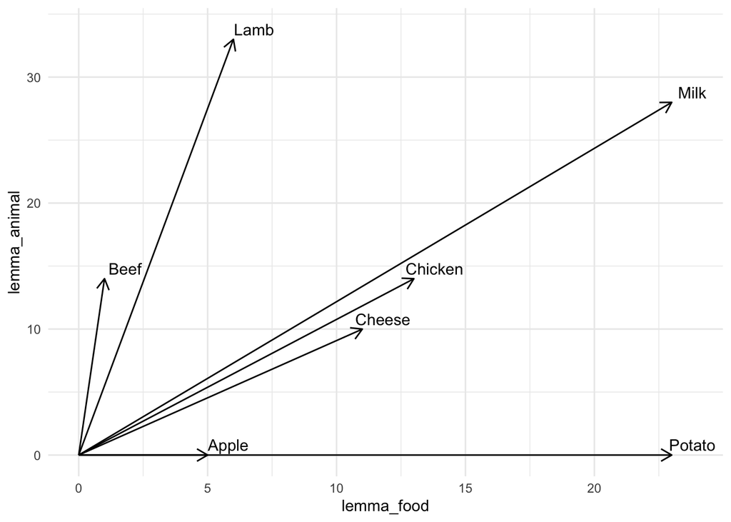

```r
tokens %>%
  sm_text_tfidf() %>%
  filter(token %in% c("animal", "food")) %>%
  select(doc_id, token, tf) %>%
  pivot_wider(
    names_from = "token",
    values_from = "tf",
    names_prefix = "lemma_",
    values_fill = list("tf" = 0)
  )  %>% filter(
    doc_id %in% c("Apple", "Beef", "Chicken", "Potato", "Milk", "Lamb", "Cheese")
  ) %>%
  ggplot() +
    geom_text(
      aes(x = lemma_food, y = lemma_animal, label = doc_id),
      nudge_x = 0.8,
      nudge_y = 0.8
    ) +
    geom_segment(
      aes(x = 0, y = 0, xend = lemma_food, yend = lemma_animal),
      arrow = arrow(length = unit(0.3,"cm"))
    )
```

The take-away from this illustration is that a wider-format of the term frequency values provides an interesting way of grouping and exploring the relationships between documents. Generally, we do not want to actually use the `pivot_wider` function because it is too slow and clunky to work with a dataset that may have thousands of columns. Instead, we will use a different approach with allows us to think of documents as living in a high dimensional space without having to work with these large dimensional spaces directly.

## Dimension Reduction

Consider extending the illustration in the previous section to include a larger set of lemmas. While we do not have an easy way of plotting the concept, we can try to imagine each document as a an arrow from the origin to a point in a very high dimensional space (one dimension for each unique token in the term frequency dataset). In this section we will see a way of trying to work with this high-dimensional space.

It was mentioned above that the `pivot_wider` function is not a good choice for making a wider version of a term frequency dataset. A better choice is the function `cnlp_utils_tf`, provided by **cleanNLP**. It produces a special kind of object that efficently stores a wide version of the dataset in an object called a “dgCMatrix”.

```r
tokens %>%
  cnlp_utils_tf(token_var = "lemma") %>%
  class()
```

```
## [1] "dgCMatrix"
## attr(,"package")
## [1] "Matrix"
```

We will not work with this object directly, but will instead see several ways of converting it back into a reasonably-sized dataset. Note that the dataset constructed here will use term frequencies. The sister function `cnlp_utils_tfidf` produces a “dgCMatrix” or TF-IDF values.

Principal component analysis is a common method for taking a high-dimensional dataset and converting it into a smaller set of dimensions that capture many of the most interesting aspects of the higher dimensional space. The first principal components is defined as a direction in the high-dimensional space that captures the most variation in the inputs. The second component is a dimension perpendicular to the first that captures the highest amount of residual variance. Additional components are defined similarly. We can compute principal components from the “dgCMatrix” using the helper function `sm_tidy_pca`:

```r
tokens %>%
  cnlp_utils_tfidf(token_var = "lemma") %>%
  sm_tidy_pca(n = 2)
```

```
## # A tibble: 61 x 3
##    document          v1       v2
##    <chr>          <dbl>    <dbl>
##  1 Apple       -0.0756  -0.146
##  2 Asparagus   -0.0625  -0.0290
##  3 Avocado     -0.139   -0.279
##  4 Banana      -0.0442  -0.0657
##  5 Chickpea    -0.0668   0.0159
##  6 String Bean -0.0184  -0.00463
##  7 Beef         0.00395  0.0310
##  8 Bell Pepper -0.0406  -0.0485
##  9 Crab         0.103   -0.0579
## 10 Broccoli    -0.0818  -0.0957
## # … with 51 more rows
```

The specific mathematics behind the principal components is less important than how we interpret the output. Generally, went we plot the first 2 or 3 components together, we do not worry about the specific dimensions. Rather, we want to use the principal components to show relationships between documents based on clusters and other proximal information. Here is a plot of our dataset on the first two principal components, colored by food group:

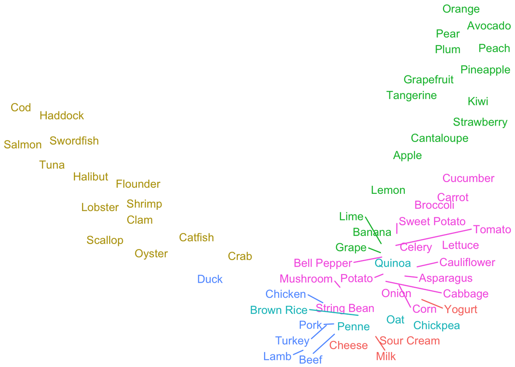

```r
tokens %>%
  cnlp_utils_tfidf(token_var = "lemma") %>%
  sm_tidy_pca() %>%
  left_join(food, by = c("document" = "item")) %>%
  ggplot() +
    geom_text_repel(
      aes(x = v1, y = v2, label = document, color = food_group),
      show.legend = FALSE
    ) +
    theme_void()
```

Another method for reducing the dimension of our dataset is called UMAP (Uniform Manifold Approximation and Projection). It has a much more complex algorithm that is able to better spread the dataset uniformly over the plot region. We can run this algorithm using the function `sm_tidy_umap`:

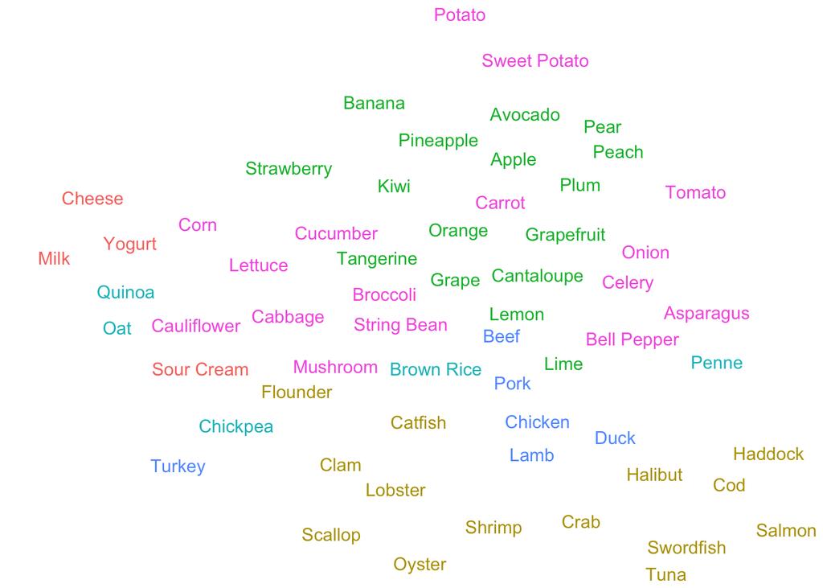

```r
tokens %>%
  cnlp_utils_tfidf(token_var = "lemma") %>%
  sm_tidy_umap() %>%
  left_join(food, by = c("document" = "item")) %>%
  ggplot() +
    geom_text_repel(
      aes(x = v1, y = v2, label = document, color = food_group),
      show.legend = FALSE
    ) +
    theme_void()
```

As with the principal components, the exact dimensions are unimportant here, its the relationship between the documents that counts. Notice that the pages are less clumped together here, but also that the structures from the principal component analysis are not as clearly defined. The benefits of UMAP become more apparent with larger datasets, which will be shown in the exercice notebooks.

## Document Distance

In the previous two sections we treated documents as being points in a high-dimensional space, and commented that our primary objective is understanding the relationships between the documents in this space. We can approach this question more directly by computing the distances between documents in the high-dimensional space. This can be done by using the `sm_tidy_distance` function applied to the “dgCMatrix” object:

```r
tokens %>%
  cnlp_utils_tfidf(token_var = "lemma") %>%
  sm_tidy_distance()
```

```
## # A tibble: 3,721 x 3
##    document1   document2 distance
##    <chr>       <chr>        <dbl>
##  1 Apple       Apple           0
##  2 Asparagus   Apple         361.
##  3 Avocado     Apple         356.
##  4 Banana      Apple         623.
##  5 Chickpea    Apple         364.
##  6 String Bean Apple         366.
##  7 Beef        Apple         449.
##  8 Bell Pepper Apple         369.
##  9 Crab        Apple         459.
## 10 Broccoli    Apple         357.
## # … with 3,711 more rows
```

The outpu gives the distance between every pair of documents. Self-pairs (the distance between Apple and Apple) are included to assist with other kinds of analysis. Using this output, we can join each page to its closest neighbor:

```r
tokens %>%
  cnlp_utils_tfidf(token_var = "lemma") %>%
  sm_tidy_distance() %>%
  filter(document1 != document2) %>%
  group_by(document1) %>%
  arrange(distance) %>%
  slice_head(n = 1) %>%
  ungroup() %>%
  arrange(distance)
```

```
## # A tibble: 61 x 3
##    document1   document2 distance
##    <chr>       <chr>        <dbl>
##  1 Flounder    Penne         29.2
##  2 Penne       Flounder      29.2
##  3 Cantaloupe  Penne         30.3
##  4 Tangerine   Penne         38.7
##  5 Broccoli    Penne         39.5
##  6 Cauliflower Broccoli      43.7
##  7 Plum        Penne         48.4
##  8 Duck        Penne         51.7
##  9 Clam        Flounder      56.1
## 10 Halibut     Flounder      57.5
## # … with 51 more rows
```

```r
tokens %>%
  cnlp_utils_tfidf(token_var = "lemma") %>%
  sm_tidy_angle_distance() %>%
  filter(document1 < document2) %>%
  group_by(document1) %>%
  arrange(distance) %>%
  slice_head(n = 1) %>%
  ungroup() %>%
  arrange(distance)
```

```
## # A tibble: 60 x 3
##    document1 document2    distance
##    <chr>     <chr>           <dbl>
##  1 Potato    Sweet Potato    0.158
##  2 Milk      Yogurt          0.247
##  3 Cod       Haddock         0.271
##  4 Orange    Tangerine       0.299
##  5 Lobster   Scallop         0.301
##  6 Clam      Scallop         0.311
##  7 Haddock   Swordfish       0.334
##  8 Swordfish Tuna            0.336
##  9 Broccoli  Cauliflower     0.337
## 10 Oyster    Scallop         0.339
## # … with 50 more rows
```

These relationships seem much more as expected, linking for example Milk and Yogurt, Potato and Sweet Potato, Broccoli and Cauliflower. We will do more with these distances as a form of network analysis in Chapter 13.

## Word Relationships

In all of the preceedhing analyses, we have focused on the analysis of the document their usage of words. We learned in Chapter 10 that there are often multiple ways of widening a dataset, each leading to different kinds of analysis. The term frequency dataset is no different. We could widen the dataset by treating each row as a term and each column as a document. It is possible to apply dimensionality reduction and distance metrics on this format as well in order to understand the relationships between words.

The easiest way to produce a “dgCMatrix” of the word relationships is by first using `cnlp_utils_tfidf` as before and then calling the function `t()` (transpose) to exchange the rows and columns. We will control the maximum number of features by setting `max_features` to 100 and only considering nouns. Here is the principal component analysis plot:

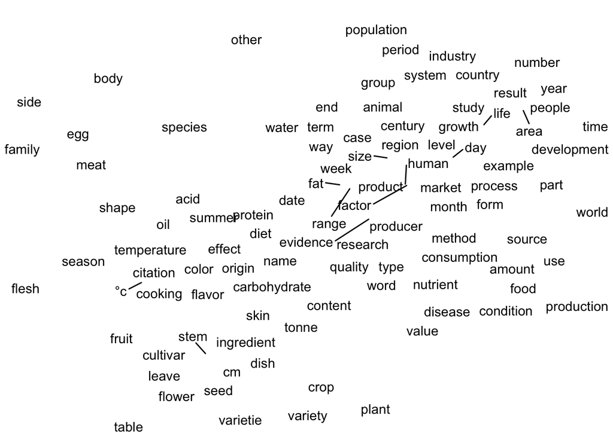

```r
tokens %>%
  filter(upos == "NOUN") %>%
  cnlp_utils_tfidf(
    min_df = 0, max_df = 1, max_features = 100
  ) %>%
  t() %>%
  sm_tidy_pca(item_name = "word") %>%
  ggplot() +
    geom_text_repel(
      aes(x = v1, y = v2, label = word),
      show.legend = FALSE
    ) +
    theme_void()
```

As well as the closest pairs of words (here we increase the number of words to 400):

```r
tokens %>%
  filter(upos == "NOUN") %>%
  cnlp_utils_tfidf(
    min_df = 0, max_df = 1, max_features = 400
  ) %>%
  t() %>%
  sm_tidy_angle_distance(item_name = "word") %>%
  filter(word1 < word2) %>%
  group_by(word1) %>%
  arrange(distance) %>%
  slice_head(n = 1) %>%
  ungroup() %>%
  arrange(distance)
```

```
## # A tibble: 399 x 3
##    word1      word2      distance
##    <chr>      <chr>         <dbl>
##  1 government power        0.0843
##  2 percent    power        0.0870
##  3 history    member       0.109
##  4 country    government   0.117
##  5 bird       egg          0.121
##  6 decade     population   0.124
##  7 member     power        0.140
##  8 city       power        0.140
##  9 bc         BC           0.140
## 10 breed      purpose      0.144
## # … with 389 more rows
```

Do these relationships seem reasonable to you? Do they tell you anything about the data or the usage of language within the data that you find surprising?